# Visual data exploration

3/13/2022

This is an **exploration** about candidate’s campaign finance data by using a few **data visualization** concepts from the book [*Fundamentals of Data visualization*](https://clauswilke.com/dataviz/index.html). The data set has 26828 rows and 50 columns, which is a combination of candidate summary file from year 2008 to 2020 obtained from the U.S. Federal Election Commission ([FEC](https://www.fec.gov/)). Each summary file covers for a two year period of candidate’s financial activity summary. For more detailed file description, please visit: https://www.fec.gov/campaign-finance-data/candidate-summary-file-description/

# Part 1. Figures with stories

A few data representations are created in part 1, along with corresponding stories. Figures convey story messages extracted from the data set and they are helpful in the exploratory data analysis. If used properly, data visualization can help understanding the data set with more intuitions.

### 1.1 Bar plot of the top 5 parties

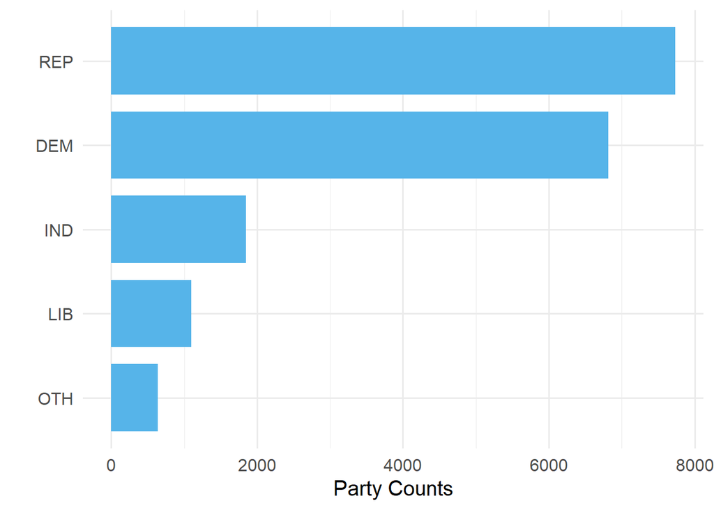

Among the top 5 popular parties, the number of candidates affiliated with the Republican Party and the Democratic Party significantly outweighs (at least 300%) candidates from other political parties. Republican and Democratic are the dominant parties in the data set.

### 1.2 Density estimates of individual contribution

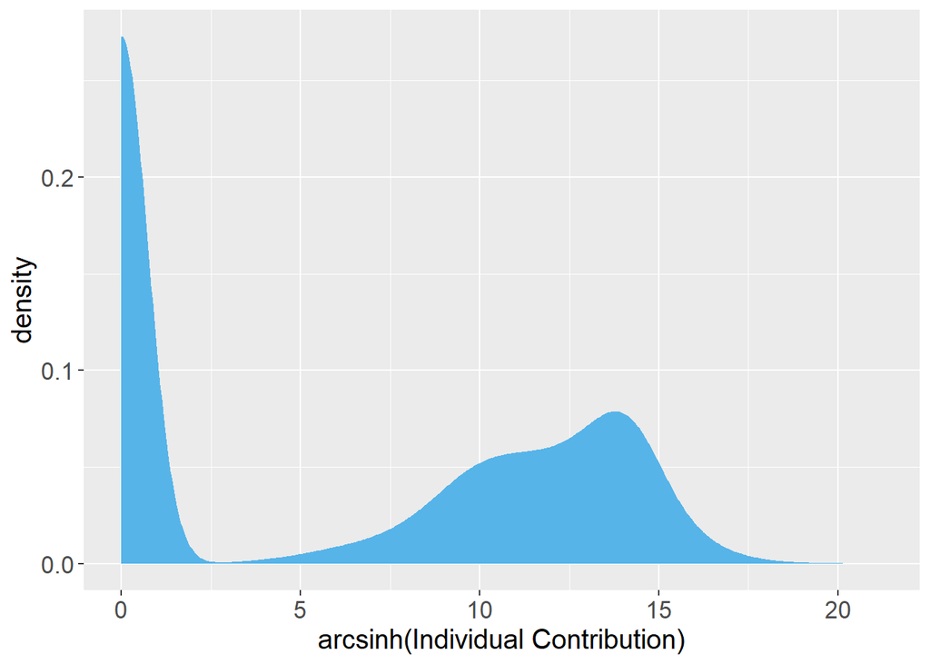

The density plot shows a bimodal distribution of total contributions from individuals. A high density of candidates made relatively low individual contribution around the mode compared to candidates who made 10 to 15 arcsinh units of individual contribution around the lower density peak.

### 1.3 Sina plot of total loan from 2020 reports

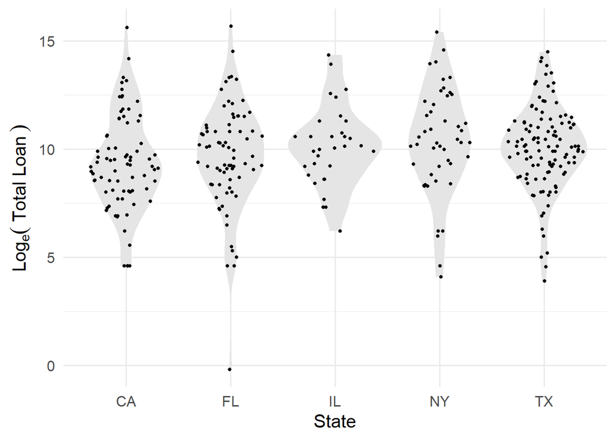

For reports in 2020, candidates from popular states tend to have a total loan located between 5 and 15 natural log of dollars, ignoring total loan being zero. There is a significantly small data point in Florida away from the cluster, so it can be an outlier.

### 1.4 Ending years of reports

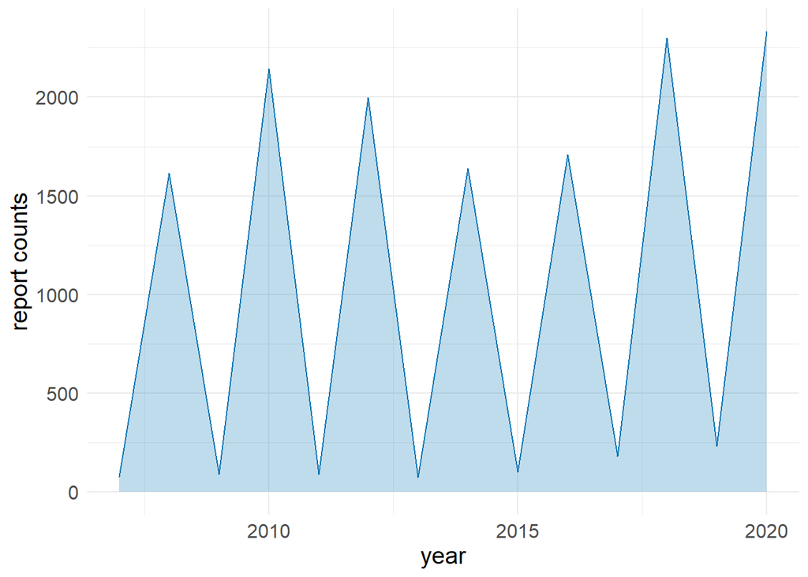

The line graph shows the ending year of reports fluctuating between odd years and even years. Majority reports ended in even years (e.g., 2010, 2020), and a minor portion of reports ended in odd years (e.g., 2015).

### 1.5 Geographical distribution of candidate office

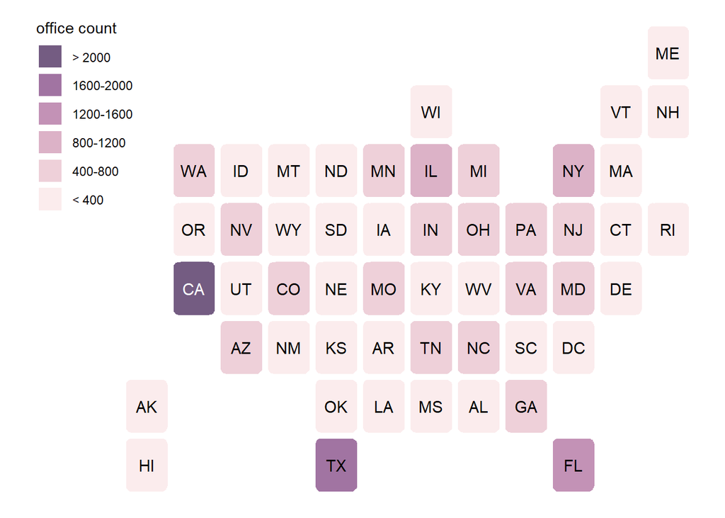

California has the greatest color depth than other states, so most candidates have their offices located in California. Also, many candidates have their offices in Texas, Florida, or New York. But there are less candidate offices in Alaska.

# Part 2. Misleading figures

Not all data representations convey the story messages clearly. In part 2, two figures (1.4 & 1.5) in part 1 are transformed, and they tell different stories that may not reflect the truth in the data set. Although these two figures are technically right, their stories can be misleading to many people who don’t look at them carefully.

### 2.1 Log transformed ending years of reports

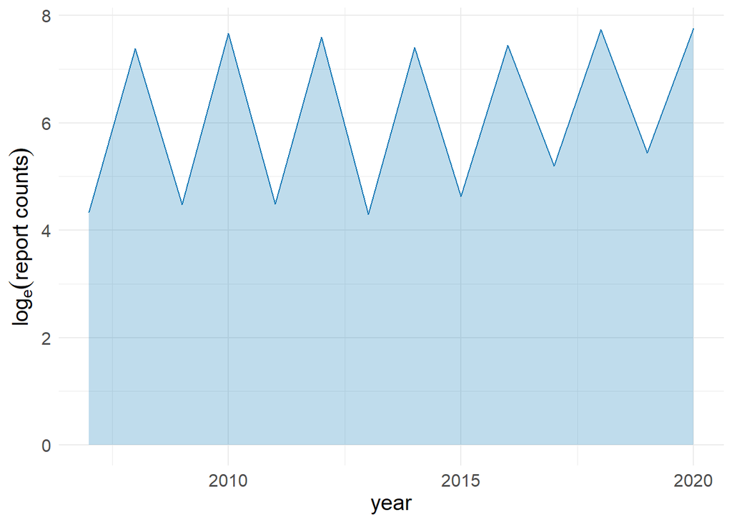

At a glance, the number of report ending years has little variations from year to year. It just varies within 4 to 8 units. Although the plot is technically right, the log transformation eases the periodic trend in the visual representation, making fluctuations less obvious. If one exponentiates the log unit, they will find the differences are actually distinct.

### 2.2 Dark colored office distribution

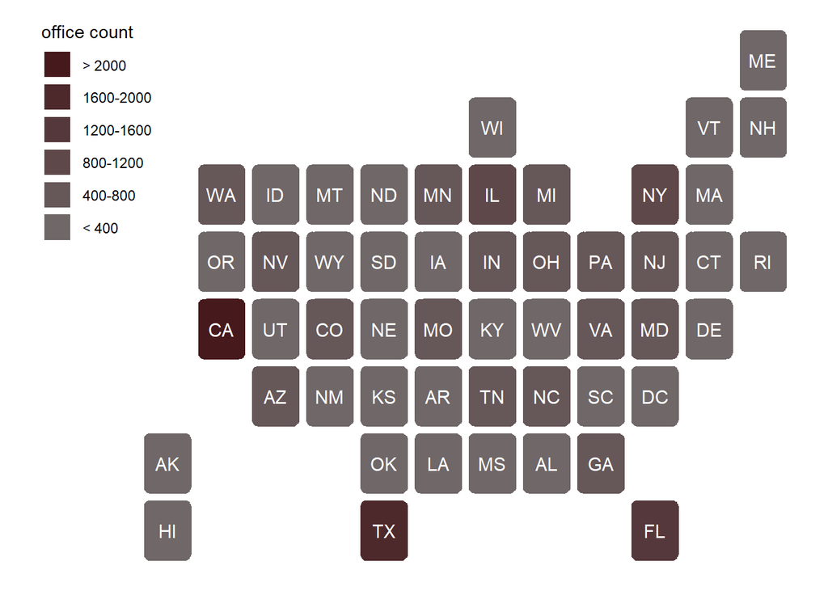

People may naturally think California and Texas are the most popular states of candidate offices (> 2000 counts). The dark color depth makes them hard to distinguish from one another. In fact, there are more than 2000 offices only in California, but not in Texas. They are not in the same category.